# SurEau at Puechabon

### 3-4 Manual settings of some parameters

You can use the object previously defined to reset soma parameters manually. But take it does not work for all paramters. for instance resseting the point of stomatal closure at 12 or 88 % won’t work because thhe model use other parameters computed internally during the creatin of the **vegetation_parameters**. If iy are not sure,, you’d better change the parameter in the input file.

```r
vegetation_parameters$gsMax = 220
vegetation_parameters$gCrown0 = 150
vegetation_parameters$gmin20 = .5
```

### 3-5 Check your input parameters graphically

You can check how your plant and stand look like using this function

```
## [1] "Look at your Stand & Soil & Plant"
```

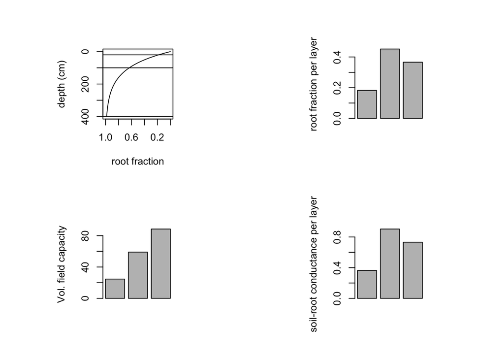

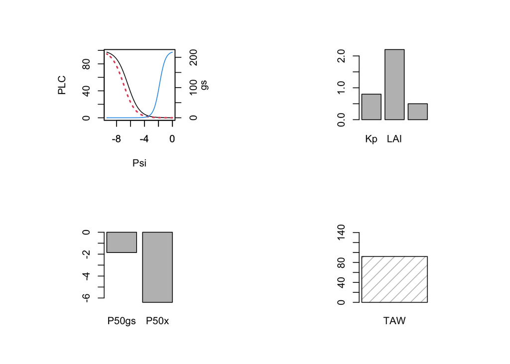

### 5 makes plot

Read output files and validation data and perform plot per year

```
## [1] "Date"       "yeardoy"    "nb.sensors" "J_Av.gap"   "J_SD.gap"
## [6] "J_SE.gap"   "E_Av.gap"   "E_SD.gap"   "E_SE.gap"
```

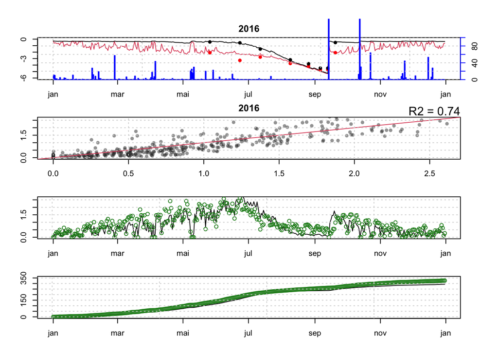

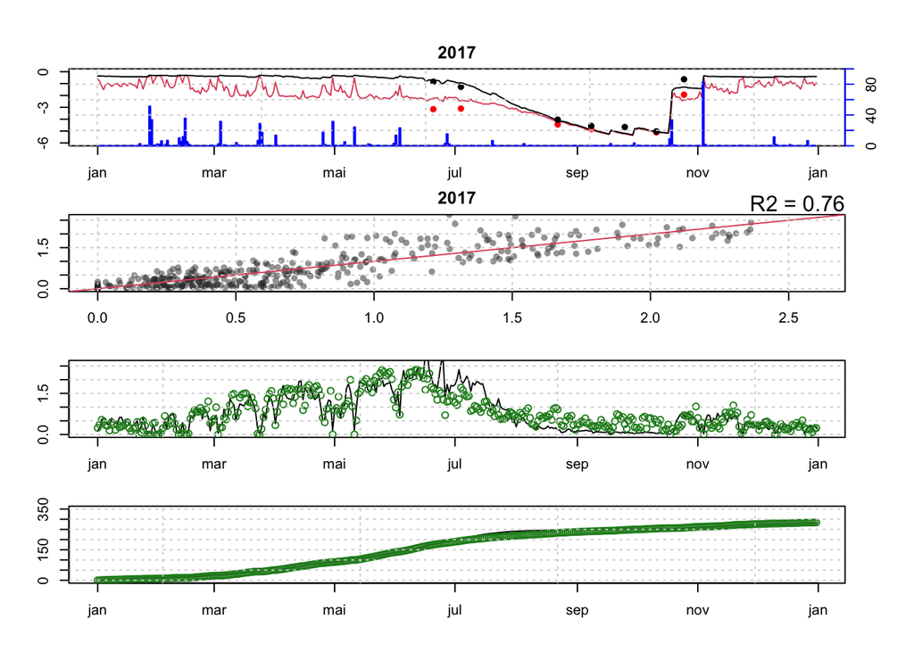

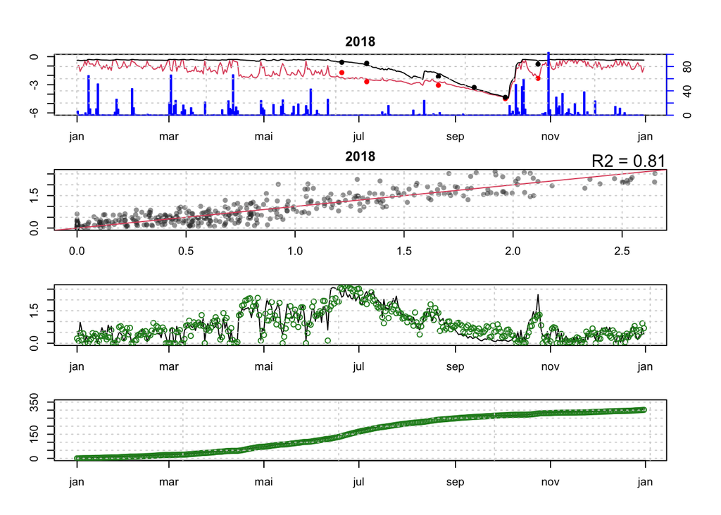